# A3

Kevin O Brien

5 December 2018

#### Author(s)

Scott Fortmann-Roe scottfr@berkeley.edu http://Scott.Fortmann-Roe.com

a3 A3 Results for Arbitrary Model #### Description This function calculates the A3 results for an arbitrary model construction algorithm (e.g. Linear Regressions, Support Vector Machines or Random Forests). For linear regression models, you may use the a3.lm convenience function. #### Usage

```
a3(formula, data, model.fn, model.args = list(), ...)
```

#### Arguments

formula the regression formula. data a data frame containing the data to be used in the model fit. model.fn the function to be used to build the model. model.args a list of arguments passed to model.fn. … additional arguments passed to a3.base.

#### Value

S3 A3 object; see a3.base for details #### References Scott Fortmann-Roe (2015). Consistent and Clear Reporting of Results from Diverse Modeling Techniques: The A3 Method. Journal of Statistical Software, 66(7), 1-23. http://www.jstatsoft.org/v66/i07/

#### Examples

```r
## Standard linear regression results:
summary(lm(rating ~ ., attitude))
```

```
##
## Call:
## lm(formula = rating ~ ., data = attitude)
##
## Residuals:
##      Min       1Q   Median       3Q      Max
## -10.9418  -4.3555   0.3158   5.5425  11.5990
##
## Coefficients:
##             Estimate Std. Error t value Pr(>|t|)
## (Intercept) 10.78708   11.58926   0.931 0.361634
## complaints   0.61319    0.16098   3.809 0.000903 ***
## privileges  -0.07305    0.13572  -0.538 0.595594
## learning     0.32033    0.16852   1.901 0.069925 .
## raises       0.08173    0.22148   0.369 0.715480
## critical     0.03838    0.14700   0.261 0.796334
## advance     -0.21706    0.17821  -1.218 0.235577
## ---
## Signif. codes:  0 '***' 0.001 '**' 0.01 '*' 0.05 '.' 0.1 ' ' 1
##
## Residual standard error: 7.068 on 23 degrees of freedom
## Multiple R-squared:  0.7326, Adjusted R-squared:  0.6628
## F-statistic:  10.5 on 6 and 23 DF,  p-value: 1.24e-05
```

```r
## A3 Results for a Linear Regression model:
# In practice, p.acc should be <= 0.01 in order
# to obtain finer grained p values.
a3(rating ~ ., attitude, lm, p.acc = 0.1)
```

```
##              Average Slope   CV R^2 p value
## -Full Model-                 54.9 %   < 0.1
## (Intercept)        10.7871 -  4.8 %     0.7
## complaints          0.6132 + 12.0 %   < 0.1
## privileges         -0.0731 -  7.7 %     0.9
## learning            0.3203 +  6.7 %     0.1
## raises              0.0817 -  2.2 %     0.4
## critical            0.0384 -  6.7 %     0.9
## advance            -0.2171 -  2.3 %     0.2
```

```r
## A3 Results for a Random Forest model:
# It is important to include the "+0" in the formula
# to eliminate the constant term.
require(randomForest)
a3(rating ~ .+0, attitude, randomForest, p.acc = 0.1)
```

```
##              Average Slope   CV R^2 p value
## -Full Model-                 50.1 %   < 0.1
## complaints          0.0519 + 25.3 %   < 0.1
## privileges         -0.0016 +  3.7 %     1.0
## learning            0.0573 + 14.5 %   < 0.1
## raises              0.0559 +  9.9 %   < 0.1
## critical           -0.0146 +  5.1 %     0.8
## advance            -0.0173 +  5.2 %     0.7
```

```r
# Set the ntrees argument of the randomForest function to 100
a3(rating ~ .+0, attitude, randomForest, p.acc = 0.1, model.args = list(ntree = 100))
```

```
##              Average Slope   CV R^2 p value
## -Full Model-                 44.3 %   < 0.1
## complaints          0.0361 + 29.2 %   < 0.1
## privileges          0.0100 -  1.4 %     1.0
## learning            0.0556 + 14.3 %   < 0.1
## raises              0.0425 +  5.4 %     0.3
## critical            0.0000 +  5.7 %     0.4
## advance             0.0000 +  2.2 %     0.8
```

```r
# Speed up the calculation by doing 5-fold cross-validation.
# This is faster and more conservative (i.e. it should over-estimate error)
a3(rating ~ .+0, attitude, randomForest, n.folds = 5, p.acc = 0.1)
```

```
##              Average Slope   CV R^2 p value
## -Full Model-                 44.4 %   < 0.1
## complaints         0.04649 + 26.7 %   < 0.1
## privileges        -0.00468 +  1.5 %     1.0
## learning           0.07076 + 12.5 %   < 0.1
## raises             0.03317 +  9.7 %     0.3
## critical           0.00000 +  2.7 %     0.6
## advance           -0.02359 +  1.9 %     0.6
```

```r
# Use Leave One Out Cross Validation. The least biased approach,
# but, for large data sets, potentially very slow.

a3(rating ~ .+0, attitude, randomForest, n.folds = 0, p.acc = 0.1)
```

```
##              Average Slope   CV R^2 p value
## -Full Model-                 47.4 %   < 0.1
## complaints          0.0558 + 26.5 %   < 0.1
## privileges          0.0000 +  3.7 %     0.9
## learning            0.0422 + 15.3 %     0.1
## raises              0.0497 + 12.1 %     0.5
## critical           -0.0316 +  1.8 %     0.9
## advance            -0.0275 +  5.7 %     0.9
```

```r
## Use a Support Vector Machine algorithm.
# Just calculate the slopes and R^2 values, do not calculate p values.
require(e1071)
a3(rating ~ .+0, attitude, svm, p.acc = NULL)
```

```
##              Average Slope   CV R^2
## -Full Model-                 27.2 %
## complaints          0.3702 + 23.9 %
## privileges          0.0797 -  5.0 %
## learning            0.1203 +  3.2 %
## raises              0.0748 +  0.2 %
## critical           -0.1381 - 11.9 %
## advance            -0.1574 +  2.8 %
```

a3.base Base A3 Results Calculation #### Description This function calculates the A3 results. Generally this function is not called directly. It is simpler to use a3 (for arbitrary models) or a3.lm (specifically for linear regressions). #### Usage

```
a3.base(formula, data, model.fn, simulate.fn, n.folds = 10,
data.generating.fn = replicate(ncol(x), a3.gen.default), p.acc = 0.01,
features = TRUE, slope.sample = NULL, slope.displacement = 1)
```

#### Value

S3 A3 object containing: model.R2 The cross validated R2 for the entire model. feature.R2 The cross validated R2’s for the features (if calculated). model.p The p value for the entire model (if calculated). feature.p The p value for the features (if calculated). all.R2 The R2’s for the model features, and any stochastic simulations for calculating exact p values. observed The observed response for each observation. predicted The predicted response for each observation. slopes Average slopes for each of the features (if calculated). all.slopes Slopes for each of the observations for each of the features (if calculated). table The A3 results table. a3.gen.default Stochastic Data Generators #### Description The stochastic data generators generate stochastic noise with (if specified correctly) the same properties as the observed data. By replicating the stochastic properties of the original data, we are able to obtain the exact calculation of p values. #### Usage

```
a3.gen.default(x, n.reps)
```

#### Arguments

x the original (observed) data series. n.reps the number of stochastic repetitions to generate.

#### Details

Generally these will not be called directly but will instead be passed to the data.generating.fn argument of a3.base.

Value A list of of length n.reps of vectors of stochastic noise. There are a number of different methods of generating noise: a3.gen.default The default data generator. Uses a3.gen.bootstrap. a3.gen.resample Reorders the original data series. a3.gen.bootstrap Resamples the original data series with replacement. a3.gen.normal Calculates the mean and standard deviation of the original series and generates a new series with that distribution. a3.gen.autocor Assumesa first order autocorrelation of the original series and generates a new series with the same properties.

#### Examples

```r
# Calculate the A3 results assuming an auto-correlated set of observations.
# In usage p.acc should be <=0.01 in order to obtain more accurate p values.
a3.lm(rating ~ ., attitude, p.acc = 0.1,
data.generating.fn = replicate(ncol(attitude), a3.gen.autocor))
```

```
##              Average Slope   CV R^2 p value
## -Full Model-                 59.2 %   < 0.1
## (Intercept)        10.7871 -  5.2 %     0.5
## complaints          0.6132 + 24.1 %   < 0.1
## privileges         -0.0731 -  1.6 %     0.2
## learning            0.3203 +  6.4 %   < 0.1
## raises              0.0817 -  3.0 %     0.3
## critical            0.0384 -  7.0 %     1.0
## advance            -0.2171 -  0.0 %     0.3
```

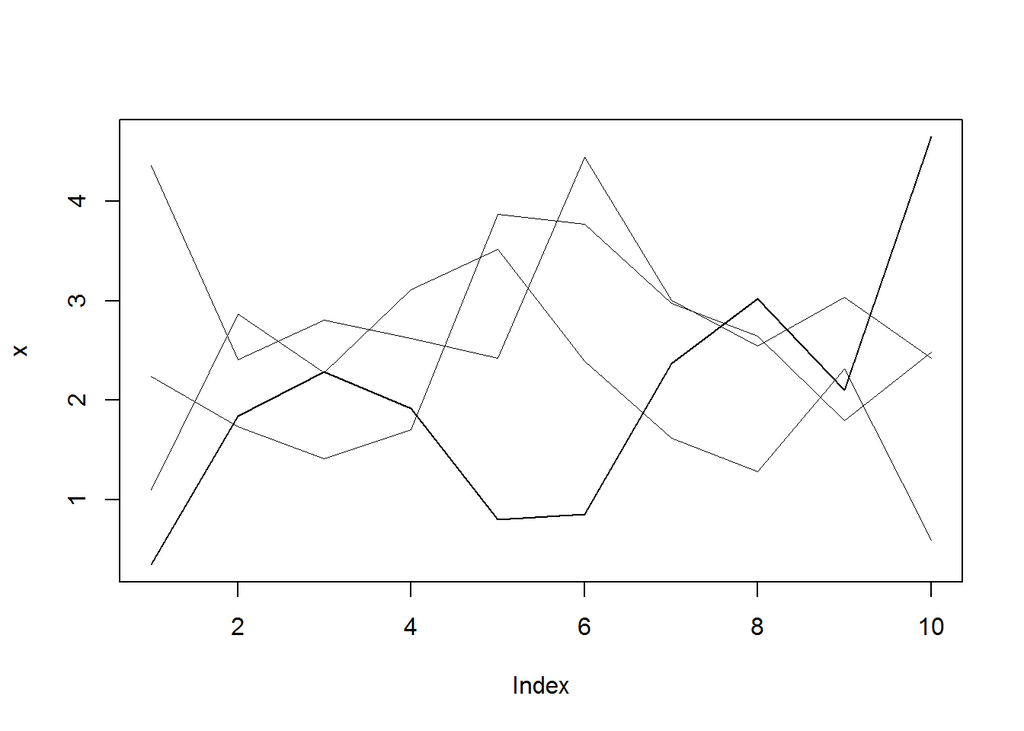

```r
## A general illustration:
# Take x as a sample set of observations for a feature
x <- c(0.349, 1.845, 2.287, 1.921, 0.803, 0.855, 2.368, 3.023, 2.102, 4.648)
# Generate three stochastic data series with the same autocorrelation properties as x
rand.x <- a3.gen.autocor(x, 3)
plot(x, type="l")
for(i in 1:3) lines(rand.x[[i]], lwd = 0.2)
```

a3.lm A3 for Linear Regressions #### Description This convenience function calculates the A3 results specifically for linear regressions. It uses R’s glm function and so supports logistic regressions and other link functions using the family argument. For other forms of models you may use the more general a3 function. #### Usage

```
a3.lm(formula, data, family = gaussian, ...)
```

#### Arguments

formula the regression formula. data a data frame containing the data to be used in the model fit. family the regression family. Typically ‘gaussian’ for linear regressions. … additional arguments passed to a3.base.

#### Value

S3 A3 object; see a3.base for details #### Examples

```r
## Standard linear regression results:
summary(lm(rating ~ ., attitude))
```

```
##
## Call:
## lm(formula = rating ~ ., data = attitude)
##
## Residuals:
##      Min       1Q   Median       3Q      Max
## -10.9418  -4.3555   0.3158   5.5425  11.5990
##
## Coefficients:
##             Estimate Std. Error t value Pr(>|t|)
## (Intercept) 10.78708   11.58926   0.931 0.361634
## complaints   0.61319    0.16098   3.809 0.000903 ***
## privileges  -0.07305    0.13572  -0.538 0.595594
## learning     0.32033    0.16852   1.901 0.069925 .
## raises       0.08173    0.22148   0.369 0.715480
## critical     0.03838    0.14700   0.261 0.796334
## advance     -0.21706    0.17821  -1.218 0.235577
## ---
## Signif. codes:  0 '***' 0.001 '**' 0.01 '*' 0.05 '.' 0.1 ' ' 1
##
## Residual standard error: 7.068 on 23 degrees of freedom
## Multiple R-squared:  0.7326, Adjusted R-squared:  0.6628
## F-statistic:  10.5 on 6 and 23 DF,  p-value: 1.24e-05
```

```r
## A3 linear regression results:
# In practice, p.acc should be <= 0.01 in order
# to obtain fine grained p values.
a3.lm(rating ~ ., attitude, p.acc = 0.1)
```

```
##              Average Slope   CV R^2 p value
## -Full Model-                 62.2 %   < 0.1
## (Intercept)        10.7871 -  1.9 %     0.6
## complaints          0.6132 + 31.5 %   < 0.1
## privileges         -0.0731 -  2.8 %     0.2
## learning            0.3203 +  7.1 %   < 0.1
## raises              0.0817 -  2.4 %     0.4
## critical            0.0384 -  4.5 %     0.8
## advance            -0.2171 -  1.3 %     0.3
```

```r
# This is equivalent both to:
a3(rating ~ ., attitude, glm, model.args = list(family = gaussian), p.acc = 0.1)
```

```
##              Average Slope   CV R^2 p value
## -Full Model-                 45.7 %   < 0.1
## (Intercept)        10.7871 -  6.5 %     0.9
## complaints          0.6132 + 22.4 %   < 0.1
## privileges         -0.0731 -  8.3 %     1.0
## learning            0.3203 +  8.9 %   < 0.1
## raises              0.0817 -  5.8 %     0.9
## critical            0.0384 -  9.3 %     1.0
## advance            -0.2171 -  2.5 %     0.5
```

```r
# and also to:
a3(rating ~ ., attitude, lm, p.acc = 0.1)
```

```
##              Average Slope   CV R^2 p value
## -Full Model-                 60.2 %   < 0.1
## (Intercept)        10.7871 -  2.3 %     0.3
## complaints          0.6132 + 29.2 %   < 0.1
## privileges         -0.0731 -  3.5 %     0.8
## learning            0.3203 + 11.2 %   < 0.1
## raises              0.0817 -  1.8 %     0.4
## critical            0.0384 -  3.2 %     0.5
## advance            -0.2171 -  1.5 %     0.1
```

a3.r2 Cross-Validated R^2 #### Description Applies cross validation to obtain the cross-validated R2 for a model: the fraction of the squared error explained by the model compared to the null model (which is defined as the average response). A pseudo R2 is implemented for classification. #### Usage

```
a3.r2(y, x, simulate.fn, cv.folds)
```

#### Arguments

y a vector or responses. x a matrix of features. simulate.fn a function object that creates a model and predicts y. cv.folds the cross-validation folds.

#### Value

A list comprising of the following elements: * R2 the cross-validated R2 * predicted the predicted responses * observed the observed responses

housing Boston Housing Prices #### Description A dataset containing the prices of houses in the Boston region and a number of features. The dataset and the following #### Description is based on that provided by UCI Machine Learning Repository (http://archive.ics.uci.edu/ml/datasets/Housing). #### Usage

[output not shown]

#### Usage

```
## S3 method for class 'A3'
plot(x, ...)
```

#### Arguments

x an A3 object. … additional options provided to plotPredictions, plotSlopes and plot functions.

#### Examples

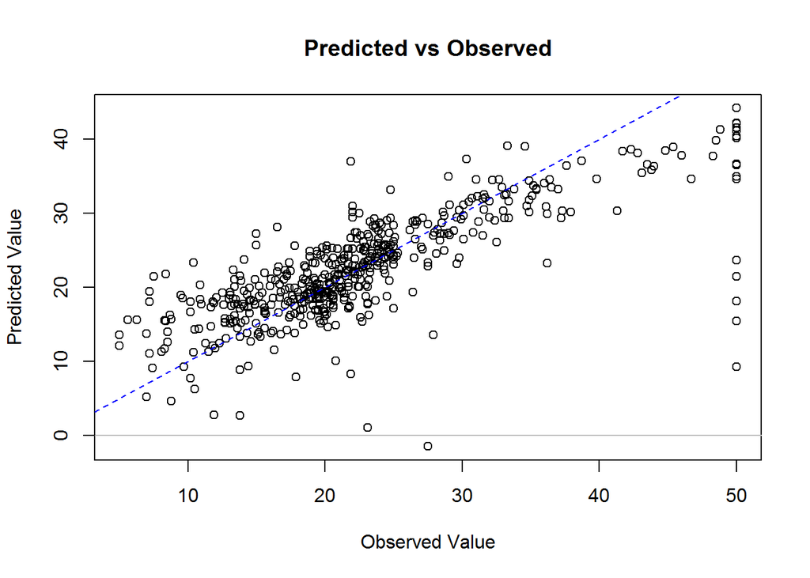

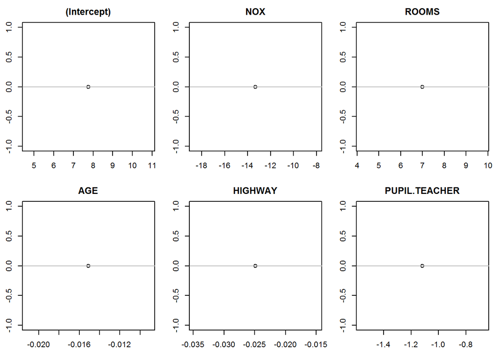

```r
data(housing)
res <- a3.lm(MED.VALUE ~ NOX + ROOMS + AGE + HIGHWAY + PUPIL.TEACHER, housing, p.acc = NULL)
plot(res)
```

plotPredictions Plot Predicted versus Observed #### Description Plots an ‘A3’ object’s values showing the predicted versus observed values for each observation. #### Usage

```
plotPredictions(x, show.equality = TRUE, xlab = "Observed Value",
ylab = "Predicted Value", main = "Predicted vs Observed", ...)
```

#### Arguments

x an A3 object, show.equality if true plot a line at 45-degrees. xlab the x-axis label. ylab the y-axis label. main the plot title. … additional options provided to the plot function.

#### Examples

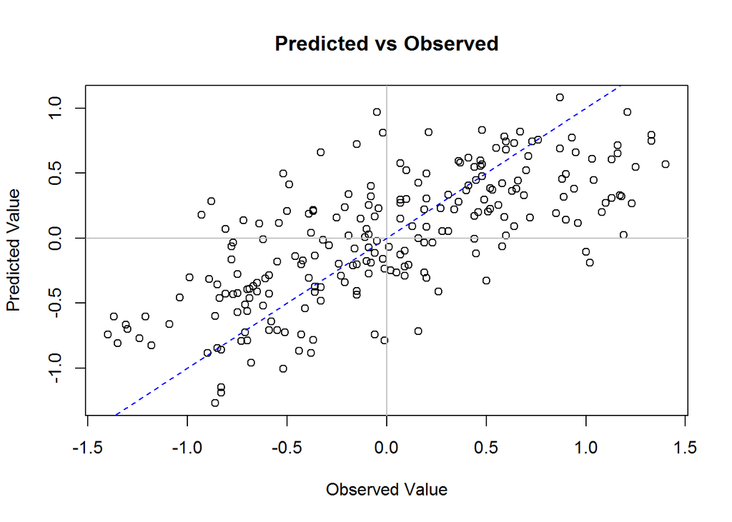

```r
data(multifunctionality)
x <- a3.lm(MUL ~ ., multifunctionality, p.acc = NULL, features = FALSE)
plotPredictions(x)
```

plotSlopes Plot Distribution of Slopes #### Description Plots an ‘A3’ object’s distribution of slopes for each feature and observation. Uses Kernel Density Estimation to create an estimate of the distribution of slopes for a feature. #### Usage

```
plotSlopes(x, ...)
```

#### Arguments

x an A3 object. … additional options provided to the plot and density functions.

#### Examples

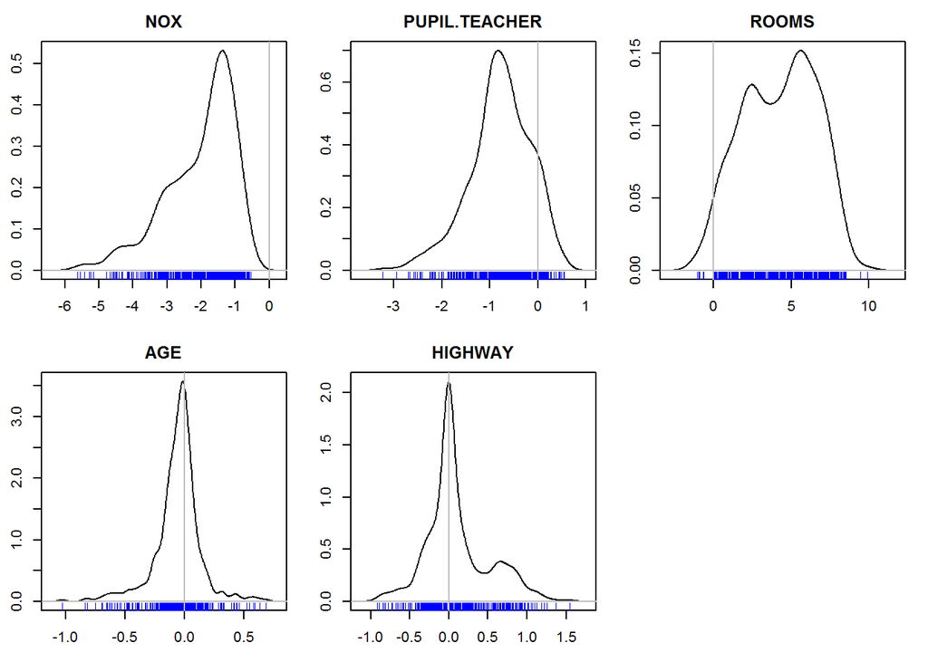

```r
require(randomForest)
data(housing)
x <- a3(MED.VALUE ~ NOX + PUPIL.TEACHER + ROOMS + AGE + HIGHWAY + 0,
housing, randomForest, p.acc = NULL, n.folds = 2)
plotSlopes(x)
```

print.A3 Print Fit Results #### Description Prints an ‘A3’ object results table. #### Usage

```
## S3 method for class 'A3'
print(x, ...)
```

#### Arguments

x an A3 object. … additional arguments passed to the print function.

#### Examples

```r
x <- a3.lm(rating ~ ., attitude, p.acc = NULL)
print(x)
```

```
##              Average Slope   CV R^2
## -Full Model-                 53.3 %
## (Intercept)        10.7871 -  6.5 %
## complaints          0.6132 + 36.2 %
## privileges         -0.0731 -  5.6 %
## learning            0.3203 -  3.5 %
## raises              0.0817 -  4.5 %
## critical            0.0384 -  7.9 %
## advance            -0.2171 -  1.5 %
```

xtable.A3 Nicely Formatted Fit Results #### Description Creates a LaTeX table of results. Depends on the xtable package. #### Usage

```
## S3 method for class 'A3'
xtable(x, ...)
```

#### Arguments

x an A3 object. … additional arguments passed to the print.xtable function. #### Examples

```r
x <- a3.lm(rating ~ ., attitude, p.acc = NULL)
xtable(x)
```

```
## % latex table generated in R 3.5.1 by xtable 1.8-2 package
## % Wed Dec 05 11:57:50 2018
## \begin{table}[ht]
## \centering
## \begin{tabular}{l|rr}
##   \hline
##  & Average Slope & CV $R^2$ \\
##   \hline
## -Full Model- &  & $58.8 \%$ \\
##   (Intercept) & $10.7871$ & $-  1.7 \%$ \\
##   complaints & $ 0.6132$ & $+ 19.9 \%$ \\
##   privileges & $-0.0731$ & $-  5.5 \%$ \\
##   learning & $ 0.3203$ & $+  8.8 \%$ \\
##   raises & $ 0.0817$ & $-  2.9 \%$ \\
##   critical & $ 0.0384$ & $-  4.0 \%$ \\
##   advance & $-0.2171$ & $-  4.9 \%$ \\
##    \hline
## \end{tabular}
## \end{table}
```